# Customer Lifetime Value

Harsha Achyuthuni

12/10/2019

In this blog I want to introduce markov chains and find out the customer life time value. Customer Lifetime Value is the net present value (NPV) of the future margin generated from a customer or a customer segment.

## Concept

*Markov Chians*  
In probability theory and statistics, a sequence or other collection of random variables is independent and identically distributed (i.i.d. or iid or IID) if each random variable has the same probability distribution as the others and all are mutually independent.  
We have a set of states, S = {s1, s2,…,sr}. The process starts in one of these states and moves successively from one state to another. Each move is called a step. If the chain is currently in state $s_i$, then it moves to state $s_j$ at the next step with a probability denoted by $p_{ij}$ , and this probability does not depend upon which states the chain was in before the current state.

That is the probability to be present in state j at time **t+1** is only dependent on the state at time **t**.
$$P_{ij} = P(X_{t+1} = j | X_{t} = i)$$

*Customer Lifetime Value* Customer lifetime value is important because, the higher the number, the greater the profits. You’ll always have to spend money to acquire new customers and to retain existing ones, but the former costs five times as much. When you know your customer lifetime value, you can improve it.

The customer segments can be represented as states of the Markov chain. Let {0, 1, 2, …, m} be the states of a Markov chain in which states {1, 2,…, m} denote different customer segments and state 0 denotes non-customer state.

The steady-state retention probability is given by
$$R_t = 1 - \frac{\pi_0(1-P_0)}{1-\pi_0}$$
Where $P_{00}$ is the transition probability of State 0, and $\pi_0$ is the steady state distribution for State 0.

Similarly Customer lifetime value for N periods is given by:
$$CLT = \sum_{t=0}^{N} \frac{P_I×P^t×R}{(1+i)^t}$$
where PI is the initial distribution of customers in different states, P is the transition probability matrix, R is the reward vector (margin generated in each customer segment). The interest rate is i (discount rate), $d = 1 + \frac{1}{1+i}$ is the discount factor.

## Data

The data is obtained from [UCI machine learning repository](http://archive.ics.uci.edu/ml/datasets/online+retail). It is a Online Retail Data Set which contains all the transactions occurring between 01/12/2010 and 09/12/2011 for a UK-based and registered non-store online retail. The company mainly sells unique all-occasion gifts. Many customers of the company are wholesalers.

A sample data is shown below

```
## # A tibble: 5 x 8
##   InvoiceNo StockCode Description Quantity InvoiceDate         UnitPrice
##   <chr>     <chr>     <chr>          <dbl> <dttm>                  <dbl>
## 1 556494    21975     PACK OF 60~        5 2011-06-12 14:57:00      0.55
## 2 564337    22326     ROUND SNAC~       24 2011-08-24 14:40:00      2.95
## 3 567180    21329     DINOSAURS ~        3 2011-09-18 14:56:00      1.65
## 4 564378    22423     REGENCY CA~        3 2011-08-25 10:26:00     12.8
## 5 538508    21429     RED GINGHA~        2 2010-12-12 13:32:00      1.65
## # ... with 2 more variables: CustomerID <dbl>, Country <chr>
```

```
##   InvoiceNo          StockCode         Description
##  Length:541909      Length:541909      Length:541909
##  Class :character   Class :character   Class :character
##  Mode  :character   Mode  :character   Mode  :character
##
##
##
##
##     Quantity          InvoiceDate                    UnitPrice
##  Min.   :-80995.00   Min.   :2010-12-01 08:26:00   Min.   :-11062.06
##  1st Qu.:     1.00   1st Qu.:2011-03-28 11:34:00   1st Qu.:     1.25
##  Median :     3.00   Median :2011-07-19 17:17:00   Median :     2.08
##  Mean   :     9.55   Mean   :2011-07-04 13:34:57   Mean   :     4.61
##  3rd Qu.:    10.00   3rd Qu.:2011-10-19 11:27:00   3rd Qu.:     4.13
##  Max.   : 80995.00   Max.   :2011-12-09 12:50:00   Max.   : 38970.00
##
##    CustomerID       Country
##  Min.   :12346    Length:541909
##  1st Qu.:13953    Class :character
##  Median :15152    Mode  :character
##  Mean   :15288
##  3rd Qu.:16791
##  Max.   :18287
##  NA's   :135080
```

As I want to calculate CLV, I want to filter for customers that have done a transaction in Dec 2010 (only they will have enough representation in all states).

```r
cust_name <- (raw_data %>% filter(month(InvoiceDate) == 12, year(InvoiceDate) == 2010, !is.na(CustomerID) ) %>%
  dplyr::select(CustomerID) %>%
  unique())$CustomerID
filtered_data <- raw_data %>% filter(CustomerID %in% cust_name) %>% group_by(InvoiceDate, CustomerID, Country) %>%
  summarise(no_trans = n(), total_sales = sum(UnitPrice), mean_sales = mean(UnitPrice), total_quantity = sum(Quantity))
```

Filter for customers that have done transaction in Dec 2010

```r
cust_name <- (raw_data %>% filter(month(InvoiceDate) == 12, year(InvoiceDate) == 2010, !is.na(CustomerID) ) %>%
  dplyr::select(CustomerID) %>%
  unique())$CustomerID
filtered_data <- raw_data %>% filter(CustomerID %in% cust_name) %>% group_by(InvoiceDate, CustomerID, Country) %>%
  summarise(no_trans = n(), total_sales = sum(UnitPrice), mean_sales = mean(UnitPrice), total_quantity = sum(Quantity))
```

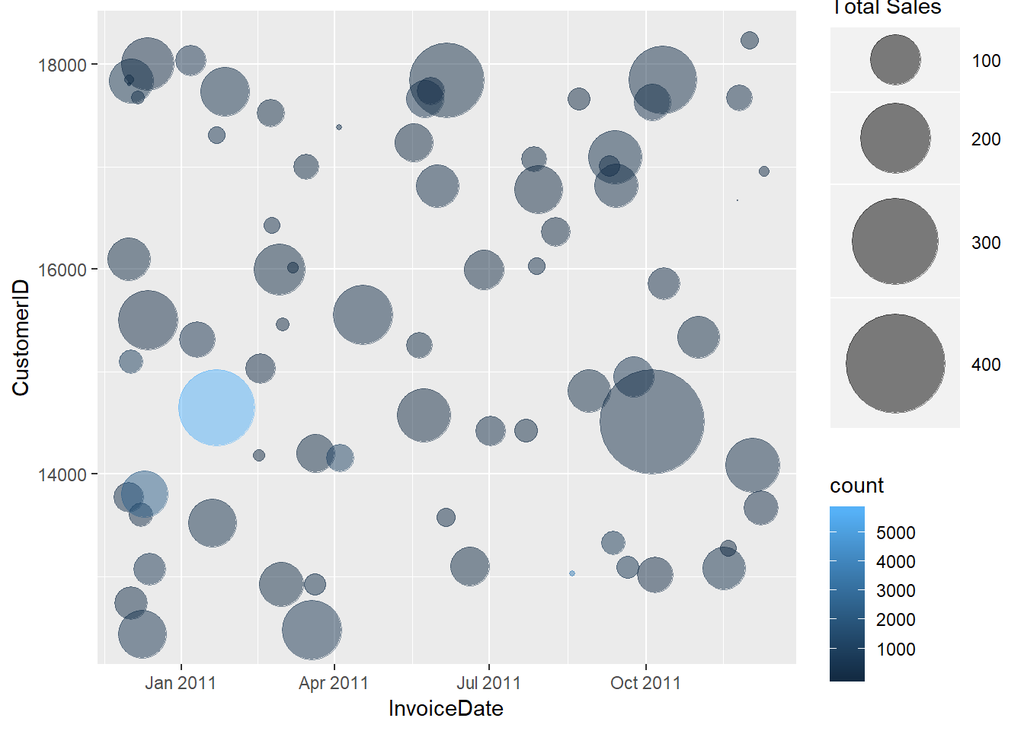

```r
ggplot(filtered_data %>% mutate(mm_yy_purchase = paste(month(InvoiceDate), year(InvoiceDate))) %>%
         # group_by(mm_yy_purchase, CustomerID) %>%
         summarise(count = sum(total_quantity), sales = sum(total_sales)) %>%
         filter(count>0, CustomerID %in% sample(cust_name, 10)),
  aes(y=CustomerID, x=InvoiceDate, size = sales, color = count)) +
  geom_point(alpha=0.5) +
  scale_size(range = c(.1, 24), name="Total Sales")
```

You can observe that there are gaps between purchases for different customers. Gap is the difference in months between two successive purchases or the difference between the current month (despite no purchase) and the last purchase month. The frequency distribution of all the purchases at different gaps is shown below:

```r
filtered_data %>% filter(InvoiceDate < date(paste0('2011-12-09'))) %>%
    mutate(recent_purchase_date = date(paste0('2011-12-09'))-date(InvoiceDate)) %>%
    group_by(CustomerID) %>%
    summarise(recent_purchase_date = min(recent_purchase_date)) %>%
    mutate(gap_month = as.integer(floor(recent_purchase_date/30))) %>%
  group_by(gap_month) %>%
  summarise(Count = n()) %>% mutate(cumsum = cumsum(Count)*100/948)
```

```
## # A tibble: 13 x 3
##    gap_month Count cumsum
##        <int> <int>  <dbl>
##  1         0   489   51.6
##  2         1   108   63.0
##  3         2    50   68.2
##  4         3    33   71.7
##  5         4    20   73.8
##  6         5    30   77.0
##  7         6    18   78.9
##  8         7    18   80.8
##  9         8    21   83.0
## 10         9     6   83.6
## 11        10    20   85.8
## 12        11    38   89.8
## 13        12    97  100
```

From the above distribution, I am assuming that a customer who has not transacted for greater than 6 months is an inactive customer.

## Creating a markov chain

At 2011-06-01, the state of each customer is given by:

```r
final_classes <- filtered_data %>% filter(InvoiceDate < date('2011-06-01')) %>%
  group_by(CustomerID) %>%
  summarise(recent_purchase_date = max(InvoiceDate)) %>%
  mutate(Class1 = ceiling((date('2011-06-01') - date(recent_purchase_date))/30)) %>%
  mutate(Class1 = as.integer(Class1))
final_classes %>% sample_n(10)
```

```
## # A tibble: 10 x 3
##    CustomerID recent_purchase_date Class1
##         <dbl> <dttm>                <int>
##  1      18075 2011-05-19 12:59:00       1
##  2      13705 2010-12-01 10:29:00       7
##  3      12971 2011-05-27 13:30:00       1
##  4      13448 2011-05-10 15:50:00       1
##  5      17181 2010-12-01 12:38:00       7
##  6      13534 2011-05-24 12:36:00       1
##  7      17865 2011-05-26 19:58:00       1
##  8      15601 2011-05-20 10:48:00       1
##  9      12731 2011-05-11 15:07:00       1
## 10      12476 2011-05-20 09:34:00       1
```

Here the states are defined as:

| State | Recency Level | Explaination |
| --- | --- | --- |
| 1 | 1 | Last purchase made this month |
| 2 | 2 | Last purchase made last month |
| 3 | 3 | Last purchase made 2 months ago |
| 4 | 4 | Last purchase made 3 months ago |
| 5 | 5 | Last purchase made 4 months ago |
| 6 | 6 | Last purchase made 5 months ago |
| 7 | 7-12 | Purchase made 6 months or before (Churn state) |

Similarly the state of the customer at the start of each month is:

```r
for(i in 7:12){
  final_classes_n <- filtered_data %>% filter(InvoiceDate < date(paste0('2011-',i,'-01'))) %>%
    group_by(CustomerID) %>%
    summarise(recent_purchase_date = max(InvoiceDate)) %>%
    mutate(Classn = ceiling((date(paste0('2011-',i,'-01')) - date(recent_purchase_date))/30)) %>%
    mutate(Classn = as.integer(Classn)) %>%
    dplyr::select(CustomerID, Classn)
  final_classes_n$Classn[final_classes_n$Classn >=7 ] = 7
  names(final_classes_n)[2] <- paste0('Class', i-5)
  final_classes <- merge(x = final_classes, y = final_classes_n, by = 'CustomerID')
}
final_classes %>% sample_n(10)
```

```
##    CustomerID recent_purchase_date Class1 Class2 Class3 Class4 Class5
## 1       17293  2011-02-04 15:54:00      4      5      1      1      1
## 2       13089  2011-05-26 11:04:00      1      1      1      1      1
## 3       17320  2011-04-17 14:09:00      2      3      4      1      2
## 4       14206  2011-04-14 16:38:00      2      3      4      5      6
## 5       13880  2011-05-06 12:28:00      1      1      1      2      1
## 6       17214  2011-04-04 16:28:00      2      3      4      5      1
## 7       18113  2010-12-06 12:31:00      6      7      7      7      7
## 8       15532  2010-12-16 16:45:00      6      1      1      2      3
## 9       14777  2010-12-16 15:27:00      6      7      7      7      7
## 10      18223  2011-05-24 17:12:00      1      1      1      2      1
##    Class6 Class7
## 1       1      1
## 2       1      1
## 3       3      4
## 4       7      7
## 5       1      1
## 6       1      2
## 7       7      7
## 8       4      1
## 9       7      7
## 10      1      1
```

I can observe that every customer moves from one class (state) to another state every month (step). According to Markov, the probability of a customer to move to state **j** at any step is only given by the previous state **i**.
$$P_{ij} = P(X_{t+1} = j | X_{t} = i)$$
For each interaction (Class1 to Class 2, month 2 to month 3, Step 3 to step 4), a transaction matrix can be created which has the probability of moving from **i** the state to **j** state.

But before we can create the one-step transition probabilities, we need to check whether the sequence of random variables form a Markov chain. This is carried out using Anderson− Goodman test which is a chi-square test of independence.
The null and alternative hypotheses to check whether the sequence of random variables follows a Markov chain is stated below:
H0: The sequences of transitions (X1, X2, …, Xn) are independent (zero-order Markov chain)
HA: The sequences of transitions (X1, X2, …, Xn) are dependent (first-order Markov chain)
The corresponding test statistic is
$$\chi^2 = \sum_{i} \sum_{j} (\frac{(O_{ij} -E_{ij})^2}{E_{jj}})$$

For the transition from state 1 to state 2, the test statistic is:

```r
verifyHomogeneity(inputList = c(final_classes[3:4]))
```

```
## Testing homogeneity of DTMC underlying input list
## ChiSq statistic is 540.6973 d.o.f are 48 corresponding p-value is 0
```

```
## $statistic
##   Class1
## 540.6973
##
## $dof
## [1] 48
##
## $pvalue
## Class1
##      0
```

As the p_value is 0, rejecting the Null Hypothesis. The data can be assumed as a first order markov chain.

The transition probability matrix for the transition form State 1 to 2 is:

```r
seq_matr <- markovchainFit(final_classes[3:4], method = "mle")
seq_matr$estimate
```

```
## Unnamed Markov chain
##  A  7 - dimensional discrete Markov Chain defined by the following states:
##  1, 2, 3, 4, 5, 6, 7
##  The transition matrix  (by rows)  is defined as follows:
##            1         2     3         4         5         6         7
## 1 0.62198391 0.3780161 0.000 0.0000000 0.0000000 0.0000000 0.0000000
## 2 0.43200000 0.0000000 0.568 0.0000000 0.0000000 0.0000000 0.0000000
## 3 0.36904762 0.0000000 0.000 0.6309524 0.0000000 0.0000000 0.0000000
## 4 0.15909091 0.0000000 0.000 0.0000000 0.8409091 0.0000000 0.0000000
## 5 0.18181818 0.0000000 0.000 0.0000000 0.0000000 0.8181818 0.0000000
## 6 0.11363636 0.0000000 0.000 0.0000000 0.0000000 0.0000000 0.8863636
## 7 0.05172414 0.0000000 0.000 0.0000000 0.0000000 0.0000000 0.9482759
```

From the above matrix, P(4,5) = 0.8409091 means that the probability of moving from State 4 to State 5 is 84%. That means that a customer that has not purchased any item in 3 months has a 84% probability of not purchasing any item the next month also.

Similarly the Transition matrix for all the steps is:

```r
sequenceMatr = list()
for(i in 1:6){
  sequenceMatr[[i]] <- markovchainFit(final_classes[(2+i):(3+i)], method = "map")$estimate@transitionMatrix
}
sequenceMatr
```

```
## [[1]]
##            1         2     3         4         5         6         7
## 1 0.62198391 0.3780161 0.000 0.0000000 0.0000000 0.0000000 0.0000000
## 2 0.43200000 0.0000000 0.568 0.0000000 0.0000000 0.0000000 0.0000000
## 3 0.36904762 0.0000000 0.000 0.6309524 0.0000000 0.0000000 0.0000000
## 4 0.15909091 0.0000000 0.000 0.0000000 0.8409091 0.0000000 0.0000000
## 5 0.18181818 0.0000000 0.000 0.0000000 0.0000000 0.8181818 0.0000000
## 6 0.11363636 0.0000000 0.000 0.0000000 0.0000000 0.0000000 0.8863636
## 7 0.05172414 0.0000000 0.000 0.0000000 0.0000000 0.0000000 0.9482759
##
## [[2]]
##            1         2          3         4         5          6         7
## 1 0.56944444 0.4027778 0.02777778 0.0000000 0.0000000 0.00000000 0.0000000
## 2 0.41843972 0.0141844 0.56737589 0.0000000 0.0000000 0.00000000 0.0000000
## 3 0.33802817 0.0000000 0.00000000 0.6619718 0.0000000 0.00000000 0.0000000
```

[output cut: 52 more lines]

The Transition Probabilities at various steps seem to follow a pattern. We can do a likelihood ratio test to test the homogeneity of transition matrices. That means I want to find out if the changes in TP across time are random and I can take a constant TP to describe the different TP;s or not.  
The Null and alternative hypothesis is: $H_0 : P_{ij} (t) = P_{ij}$ $H_1 : P_{ij} (t) \neq P_{ij}$

The test statistic for a likelyhood ratio test (Chi-square test) is given by
$$\chi^2 = \sum_{t} \sum_{i} \sum_{j} \frac{n(t)[\hat P_{ij}(t)-\hat P_{ij}]^2}{\hat P_{ij}}$$
where n(t) is the number of customers in state i at time t. The test statistic follows a $\chi^2$ distribution with (t − 1) × m × (m − 1) degrees of freedom.

```r
verifyHomogeneity(sequenceMatr)
```

```
## Testing homogeneity of DTMC underlying input list
## ChiSq statistic is 1.932987 d.o.f are 240 corresponding p-value is 1
```

```
## $statistic
## [1] 1.932987
##
## $dof
## [1] 240
##
## $pvalue
## [1] 1
```

As the p-value is greater than the $alpha = 0.05$, I am retaining the Null hypothesis that the transition probabilities are homogeneous.

## Customer Lifetime value

Now that we have established that the customer segments can be represented as a marcov chain, we can compute the customer lifetime value.  
The monetary value at each state is

```r
revenue_in_states <- filtered_data %>% left_join(final_classes, by = 'CustomerID') %>%
  filter(InvoiceDate >= date('2011-06-01')) %>%
  dplyr::select(Class1, total_sales) %>%
  group_by(Class1) %>%
  summarise(future_avg_revenue = mean(total_sales))
revenue_in_states
```

```
## # A tibble: 7 x 2
##   Class1 future_avg_revenue
##    <int>              <dbl>
## 1      1               54.7
## 2      2               69.8
## 3      3               84.5
## 4      4               59.7
## 5      5               40.9
## 6      6               59.0
## 7      7               58.6
```